# Project 2:Exploratory Data Analysis on Motor Insurance Fraud

ANTO JOSEPH

28/04/2021

## 1. Problem Statement

The company has a historic dataset of previous claims including the once which where found as fraud claims. The dataset contains the name of the **driver** and the **passenger**, **age** of the driver, **address**, the **repair cost** and the **fraund flag** indicating if the claim was fraud or not.

The purpose of the project is to conduct an exploratory data analysis on the dataset and find insights on the data, which can be used by the insurance company to create a model to easily identify fraud claims. The Age is the only numerical column in the dataset, repaircost is ordinal and fraudFlag is a nominal categorical data.

## 2. Solution Statement

The data will be first pre processed by cleaning the data, the data will be checked for any missing values, duplicated and typo errors.We will transform the data using feature engineering to create new columns, which will be used for exploratory data analysis. The age column will be binned into different age category. A passenger flag will be created to check if a fellow passenger was present at the time of the accident.From the address column we will separate the areas, to identify the high risk areas. Using the gender library we will try identify the gender of the drivers. Based on the feature engineered columns, we will plot the graphs to find interesting insights hidden in the data.

## 3. Exploratory Analysis

### 3.1 Libraries used and Import data

#### 3.1.1 Library

We will be using the **tidyverse** library, which will include most of the functions we will be using for this exploration. For the purpose of identifying the gender of the sample drivers, we have used the **gender** and **genderdata** .

#### 3.1.2 Import Data

The dataset provided by the company is a CSV file with the file name **“assignment_data.csv”**, we have kept the file in the root folder. We will be using the **‘read_csv()’** function to read the file. The file will then be converted to a tibble using **‘as_tibble()’** and stored in a variable called *df*.

### 3.2 Data Clensing

For the purpose of analysis we need to pre-process the data. We will checking for the missing values in the data, will replace the missing values where ever necessary. Duplicate data in the dataset can cause bias the analysis. Then we will check for consistency of the data entered.

#### 3.2.1 Missing Data

Using **is.na()** function we check for missing values in the columns. We use **colSums()** function to count the number of missing values in the columns.

#### 3.2.2 Duplicate Data

Next we will check for duplicate values in the dataset. We use the **distinct()** function on the columns **driver, age & address**, if any duplicate entry is in the dataset the number of rows will reduce. The **nrow()** is used to check the row size. We find the row count remains unchanged at 1000 implying no duplicate values in the dataset.

#### 3.2.2 Typos in Data

Typos may be present in the data, due to errors while manually entring the data. From the import data section we see the **addrress** column have typos. We will look for rows with special characters in them using the **str_which()** function, used to find patterns in the string, the function will return the row numbers having special characters in the address column.

### 3.3 Features engineered to improve EDA visualisations

For extracting useful insights from the raw dataset, we will use feature engineering. As the age is spread across 20 to 85, we will categorize the age into four categories. A passenger flag will be crated to check if there was a fellow passenger was present during the accident. We will try to extract out the area from the driver address. Using the gender library we will try to determine the gender of the driver. The gender library uses the historic data from the census to predict the gender, based on the year of birth.

#### 3.3.1 Binning Age

For the purpose of categorizing the age of the driver we will do binning on the **Age** column. This will help in exploring the data based on the category. We will create a new column **ageCategory** to categorize the age and split as below :

| Age | ageCategory |
| --- | --- |
| 0-29 | teen |
| 30-45 | adult |
| 45-60 | elderly |
| 60-Infy | retired |

#### 3.3.2 Flag for Passenger

A new column is created called **passengerFlag**, which will capture the data if either **One passenger** or **Two Passenger**, was present while the accident happened or **No passenger** was present.

```
## # A tibble: 6 x 4
##   driver         passenger1     passenger2 passengerFlag
##   <chr>          <chr>          <chr>      <chr>
## 1 MARY BRENNAN   <NA>           <NA>       No Pasenger
## 2 JOSEPH COLLINS <NA>           <NA>       No Pasenger
## 3 ROBERT WALSH   <NA>           <NA>       No Pasenger
## 4 KEVIN OCONNELL <NA>           <NA>       No Pasenger
## 5 BRIAN CULLEN   MICHAEL BROWNE <NA>       One Passenger
## 6 SEAN KAVANAGH  <NA>           <NA>       No Pasenger
```

#### 3.3.3 Group by Address & Location

```
## [1] 13
```

#### 3.3.4 List of previous offenders

From the existing data we will create a list of people who have previously involved in a fraud claim, this includes the **driver, passenger1 & passenger2**. For this purpose we will filter the dataset when the fraudFlag is TRUE. The new list **offenderList** have the names of offenders who where involved in a fraud claim and the number of times they where involved. This can be used by the company to generate a black list for repented offender.

#### 3.3.5 Gender of the driver

We will try to find the gender of the driver using the library **‘gender’** and take the data from the **‘genderdata’**. The function ‘gender_df’ requires a data frame with the first name and year of birth. Assuming the dataset is from 2021,Age is used to calculate the year of birth. we store these details in the variable **df_firstName** and pass it to the variable. The gender output is then merged with the databse and is stored in **df_driverGender** for further visual exploration.

### 3.4 Exploratory Analysis by Visualisation

With the help of graphs, an exploratory analysis through visualization is don on the dataset. We have plotted the feature engineered columns against the fraud flag column to get insights on trends on fraud claims.

#### 3.4.1 Repair Cost and Fraud Category

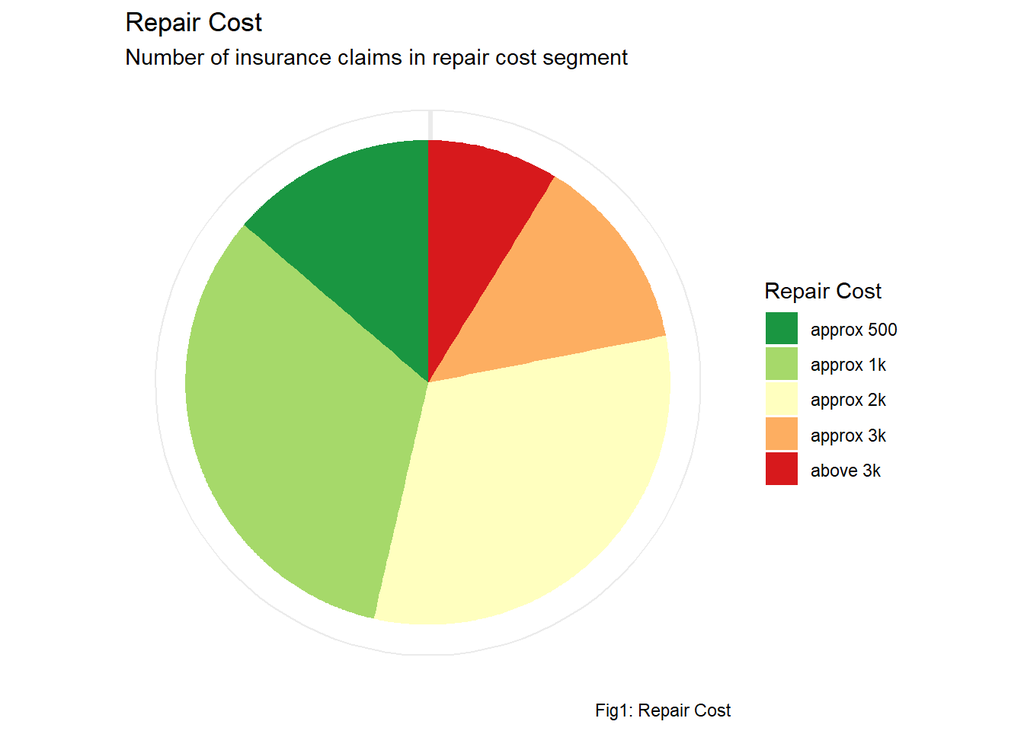

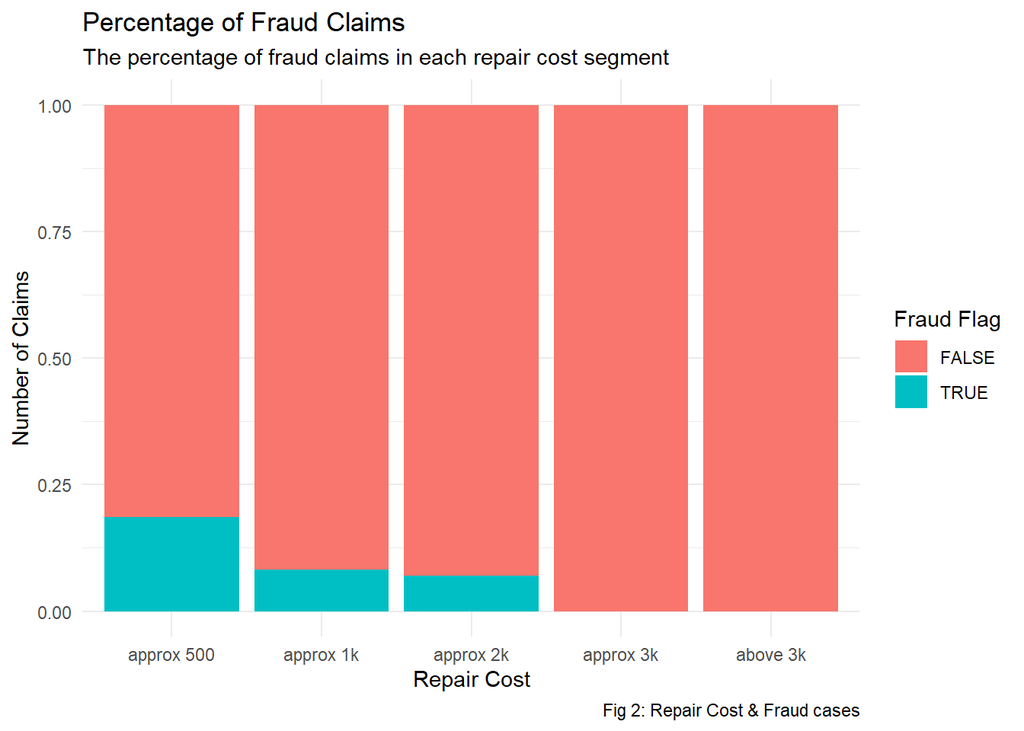

In Fig 2, we have done the percentage of fraud claims in each repair cost segment. We find it interesting to note that, most fraud claims come with an approx repair cost of 500 euros and decrease as the repair amount increases. We can find zero fraud claims for three thousand euros and more. This can be a indicator in identifying fraud cases.

#### 3.4.2 Age Category and Fraud cases

We have categorized the data into four category as teen,adult,elderly and retired and plotted the the number of claims in each age category. A summary into the age category shows that the number of samples in the adult and teen category is more compare top the retired, this can affect the analysis. We have normalized the data by the taking the percentage in each age category by **y =..count../sum(..count..)**, when plotting.

```
##
##    teen   adult elderly retired
##     275     356     228     130
```

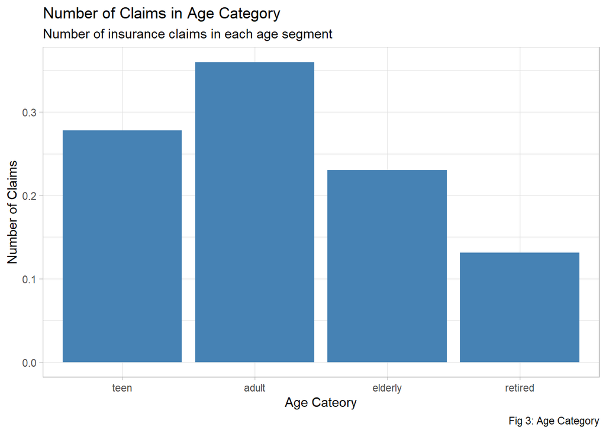

In Fig 3, we finds that adults have the most number of accident claims followed by teens.Adults are the the working class people who will be taking the most number of rides in a day increasing the chance of an accident and the teens tend to drive rashly increasing there risk of an accident. We find that people tends to be more careful when they are above 45 years, one reason may be this category of the elderly and retired tends to avoid unnecessary travels and will be more careful while driving.

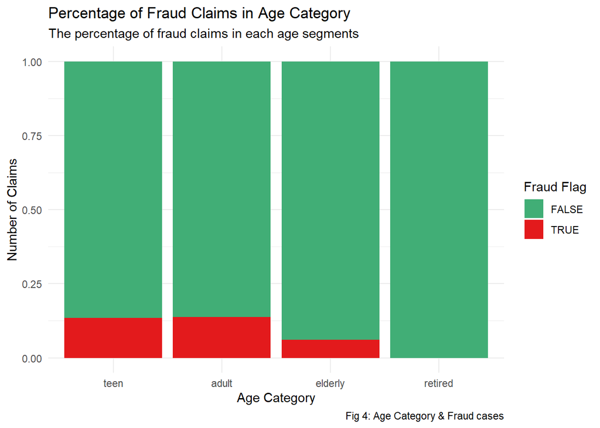

In Fig 4, When we check the number of fraud claims done in each age segment we find that the percent of fraud claims are more in the teen and adult category, followed by elderly. There seems to be zero fraud claims in the retired category.

#### 3.4.3 Number of cases in an Area

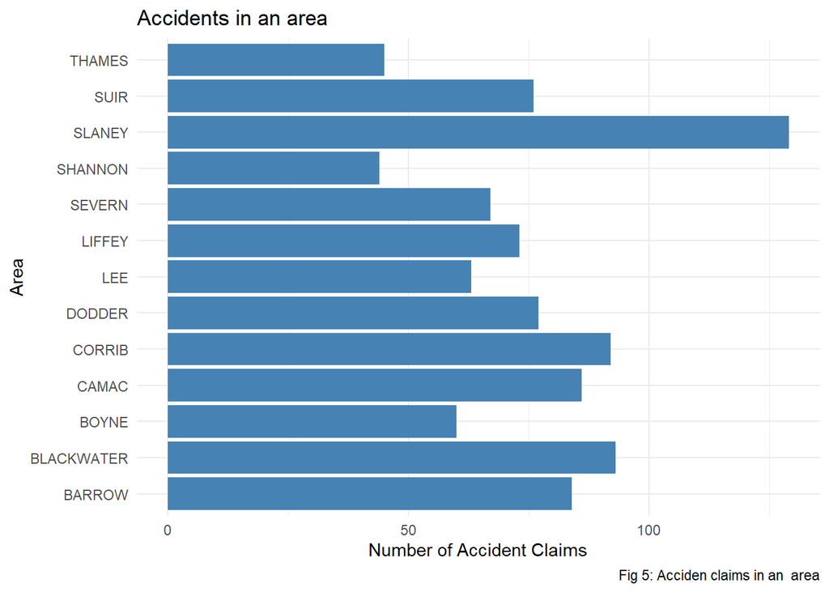

In the feature engineering section 3.3.3,we have separated the address into **area** and **locality**, and we have calculated the number of fraud and non fraud claims in the areas and have stored in the variable **df_AreaGrouped**. We will use this data to identify the area based on the fraud flags.

[figure not shown]

From the above scatter plot (Fig 6),we see that Severn has the highest number of fraud claims. We have some interesting findings here, even though the total number of claims from Thames and Shannon are very less compared to other areas we can see that the number of fraud cases are very high compared to other areas. All other areas seems to have relatively the same amount of fraud claims. Identifying areas with more fraud claims can help the claims department in tracking the fraud cases.

#### 3.4.4.Percentage of Repair cost in each Age Category

In the below section (Fig 7) we can see how the repair cost is distributed in each of the four age categories. We find the repair cost above three thousand increases slightly with age. For adults we find an increase in the claims for repair cost in the five hundred range compared to other age categories. Teens have the least repair cost cases in claims for above three thousand.

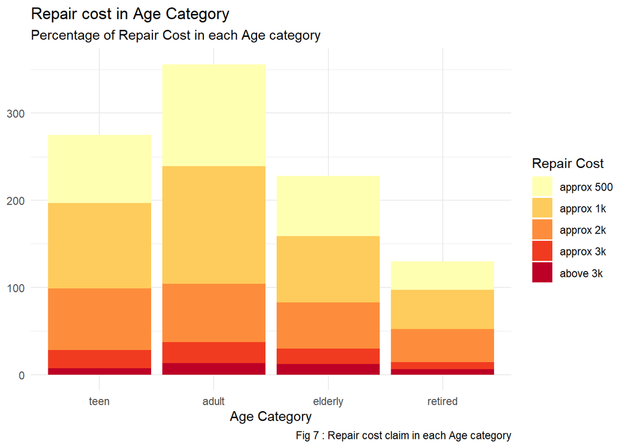

#### 3.4.5. Cost of Repair claim in an Area

We have plotted (Fig 8) the percentage of repair cost in each category for the areas. We find that the Shannon area have no claims above three thousand euros, on the contrary the Thames area have more claims in the above three thousand category. All other areas shows an even claim rate in the repair cost categories.

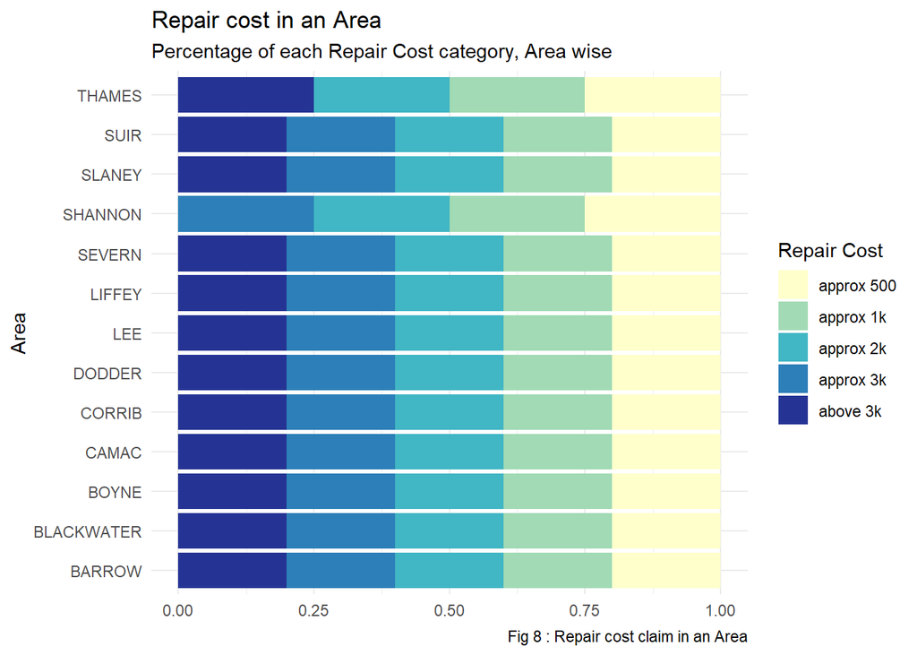

#### 3.4.6 Fraud cases with a Fellow Passenger

From the below graph (Fig 9), we find that the chance of having a fellow passenger is more for fraud cases. Its interesting to note that the number of fraud cases is almost 60% when there are two fellow passenger. There is a 10% chance of committing fraud with a single fellow passenger and there is a very negligible chance of committing fraud when the driver is alone. This may be because the fraud claims try to bring in more witnesses for strengthening the claim.

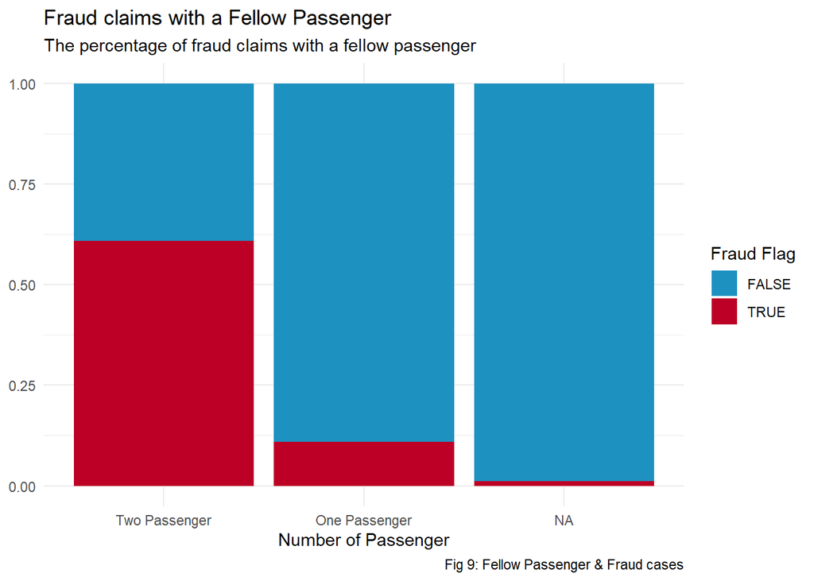

#### 3.4.7 Gender Analysis

From the below plot (Fig 10), we can see that the number of accident claims for the males are very high compared to female. This might be because the number of male drivers are high compared to females.

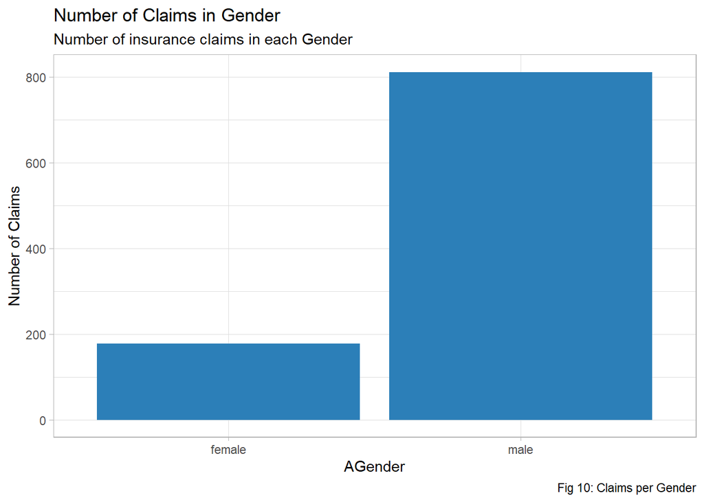

We find it interesting that even though the number of male drivers are more from Fig 10, when we compare the percentage of fraud claims the Female category shows comparatively more than Males.

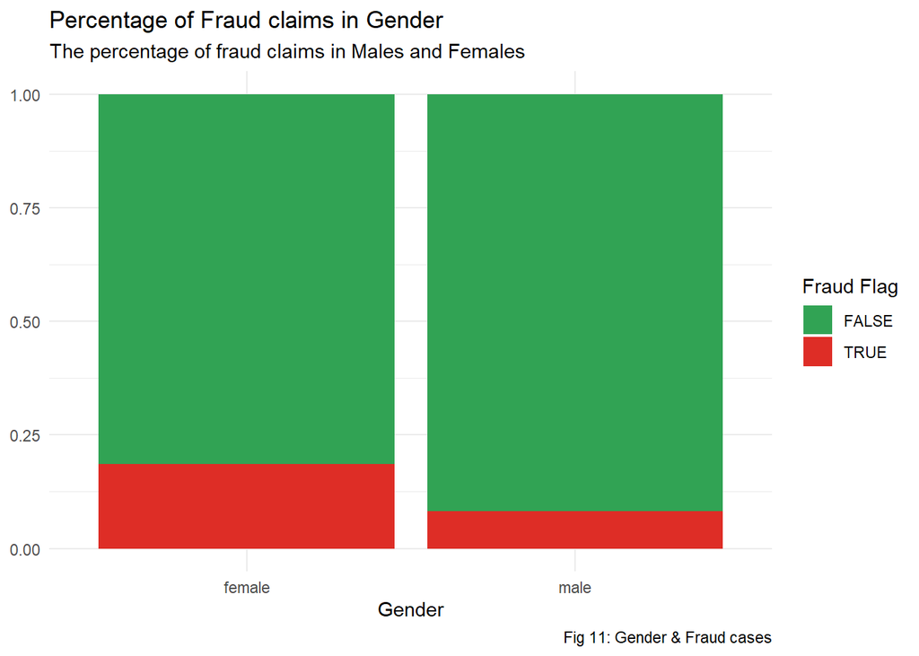

#### 3.4.7 Repeted Offender Black List

We have taken the list of repeated offenders who where involved in a fraud claim as a driver or as a fellow passenger. When we check the list we can identify 122 distinct offenders.

```
## [1] 122
```

[figure not shown]

## 4. Conclusion

From the visual exploratory analysis we can see that half of the repair claims comes under one thousand euros and most fraud claims comes in the cheaper claims. There is zeor fraud claims for three thousand euros and above. When it comes to the age adults and teens, are found to involve in fraud claims, where as the retired category never gets involved in fraud claims. Its interesting to note that the number of motor accident claims is more in adults followed by teens and elderly, the number of drivers in retired category will be comparatively less and will avoid rash driving indicating the low count.

The area of the driver is found from the **address** column, we find that the number of motor accident claims in the Slaney area is very high, Shannon and Thames have the lowest number of claims.We find it intriguing that even though the number of claims from shannon and Thames are low, the number of fraud claims is very high in these areas, compared to Slaney and Suir which has more number of accidents. This gives a scope for investigating in the above areas on why the disparity in the claims, there maybe inside dealing in the Slaney ans Suir areas for approving the fraud claims which need to be investigated.

Repair cost in the age categories shows that the number of claims in the five hundred and one thousand is more for adults. When we compare the area based on the claims we find that almost all the areas have approx 20% claims in each repair category with the exception of Shannon, where it has no claims in the above three thousand category.

Based on the fraud flag we have created the name of offenders who where involded in a claim which was identified by the company as fraud. These customers have been inolved in the fraud as a driver or a fellow passenger. we can notice repeated offenders in the list. Based on the above finding we can create a model based on the age, repair cost, gender and areas, which will predict with a certain accuracy if a claim is fraud or not.